#### CS 151: Intro to Programming in Python

# Final

### 3 hours

### A. Intro [Show]

### A. Intro [Hide]

## Intro

This will be a project-style final exam, restricted to be completable in 3 hours.

There are 5 milestones corresponding to exam problems:

- Prob0 is "Data Structures"
- Prob1 is "Interactive Graphics"
- Prob2 is "Reading Python"
- Prob3 is "Defining Classes"
- Prob4 is "Fundamental Python"

After focusing this term on many of the famous historical computer scientists who programmed computers, this assignment focuses on the people and the land that make physical computing devices. It is centered on the plurinational state of Bolivia and whose lithium mines and miners form a critical part of the global technology landscape, specifically a flag used by the peoples that live within those mountains and work within thoe mines.

The people of Andes have been fighting to maintain self-determination (what people in the US often call "independence") in the face of large US-based tech companies for years, and we should be cognizant of their struggle and their story.

You can read more in imgs/README.md at your leisure.

### B. Files [Show]

### B. Files [Hide]

## Files:

- Update these files:
  - flag.py
  - ColorObj.py
- You will also need code files:
  - pgl.py
- You will also need data files:
  - imgs/
  - rojo.png
  - naranja.png
  - amarillo.png
  - blanco.png
  - verde.png
  - azul.png
  - violeta.png
- Provided for ethical reasons:
  - imgs/README.md

#### Resources on PGL (Portable Graphics Library):

- [Prof. Jed Rembold notes on PGL (and more)](https://jrembold.github.io/Website_Backup/class_files/cs151/PythonSummary.html)
- [Prof. Eric Roberts notes on PGL](https://willamette.edu/~esroberts/python/pgldoc/)

### 0. get_color_at (10 pts) [Show]

### 0. get_color_at (10 pts) [Hide]

**Implement** `__init__` **and** `get_color_at` **in** `ColorObj.py`

When you first download the template code and run "flag.py" you should get a 700 by 700 blank image. This is because the example code uses the color from ColorObj, and ColorObj is not yet implemented.

For Prob0, you should update `__init__` and `get_color_at` to return an appropriate color given some initializing name. These names should correspond to the colors included in `rgbs.json`

- rojo
- naranja
- amarillo
- blanco
- verde
- azul
- violeta

The file is located at the following URL: https://cd-public.github.io/courses/cs1/exams/rgbs.json. The URL for is included in the template code:

```
URL = "https://cd-public.github.io/courses/cs1/exams/rgbs.json"
```

To determine the color, you will need to read it from `rgbs.json`

#### 0a. `read_rgbs`

Two important pieces of information are stored in `rgbs.json`:

1. The order of colors, and
2. The red-green-blue (rgb) color values of colors.

Write a function `read_rgbs` that reads from `rgbs.json` to determine this information. You may make your own implementation decisions, but my `read_rgbs` returned a list (in the order colors were given) of `ColorObj` objects that stored the name and rgb values of a color.

#### 0b. `get_color_at`

For each of the colors from the file, create a `ColorObj` that stores the color name, the color rgb value, and can store other information in the future.

You may wish to use `GImage.create_rgb_pixel` to additionally store a pixel that corresponds to that color, at least for now.

Write `ColorObj.get_color_at` such that it returns a pixel of the appropriate color regardless of the row-by-col location provided. We will use row-by-col locations on latter problems.

Here is an example:

```
rojo = colors[0]
rojo.get_color_at(500,500) # 4292545043
```

You can check this value using a print statement.

You will be able to tell when you have correctly implement these two methods when your graphics window changes from the default white to the "rojo" color.

### 1. `flag` (20 pts) [Show]

### 1. `flag` (20 pts) [Hide]

**Implement** `flag` **in** `flag.py`

Specifically, this flag has its longest diagonal in white, which corresponds to the "Qullasuyu" flag. We will enable other flags in Prob2.

For this and all following problems, you should use your ColorObj's for each of the 7 flag colors that you made in Prob0 - mostly take make things easier in the future.

Loop over the pixels in the pixel array used within the `flag` function, and for each row-by-col location determine from which ColorObj the current pixel should be "gotten" with `get_color_at`. For example, along the long diagonal, the "blanco" ColorObj would be appropriate.

There are both technically and algorithimically correct ways to do this. Look at the patterns in rows, columns, and diagonals, and remember colors from a file came in a certain order. Before implementing a brute force solution, you may wish to read Prob2.

You are ready to move onto the next problem when you have made the flag.

### 2. Region (20 pts) [Show]

### 2. Region (20 pts) [Hide]

**Implement the region argument to** `flag` **in** `flag.py`

This flag represents Indigenous people across what is today termed the "Andes", and the flag with long "blanco" diagonal often specifically represents the "Qullasuyu" (Qulla region). There are other regions that have other colors on the long diagonal, but are otherwise identical. Here are the examples you must be able to make:

| Suyu | Color |
| --- | --- |
| Chinchaysuyu | rojo |
| Kuntisuyu | amarillo |
| Qullasuyu | blanco |
| Antisuyu | verde |

`flag('Qullasuyu')`

`flag('Antisuyu')`

`flag('Kuntisuyu')`

`flag('Chinchaysuyu')`

### 3. Pixel Array (30 pts) [Show]

### 3. Pixel Array (30 pts) [Hide]

**Store images that correspond to colors rather than color data in** `ColorObj` **in** `ColorObj.py`

In brief, the flag colors represent aspects of Plurinational Andean life and I have chosen images from to represent these aspects as best as I can, which are included in the `imgs` folder with the starter code, named for the color to which the image corresponds.

For this milestone, instead of returning a literal color value from the `ColorObj`, return a metaphorical color value from an image at the same row-by-col location.

- Read these images from their files using `GImage`
  - For example, the "rojo" image is located at "imgs/rojo.png"
- Extract the pixel array from the `GImage` using `.get_pixel_array()`
- 3a. Crop the images to be squares, like the flag
- 3b. Resize the images to exactly fill the GWINDOW_SIZE
- Update `get_color_at` to get a pixel from the image pixel array, rather than returning a single color in all cases.

You are not required to do 3a and 3b separately, and will receive the full 30 pts if your Prob3 is correct. However, if you struggle on Prob3, you may receive partial credit for these methods.

#### 3a. `square` (10 pts)

Each image in the `imgs` folder is not a square, and the flag is. For each pixel array, remove pixels from the left/right or top/bottom to make it square and centered.

*Example* `verde.png` shows a Bolivia lithium mine, "el símbolo de las riquezas naturales" (the symbol of the natural resources), that is 800 pixels wide and 448 pixels tall.

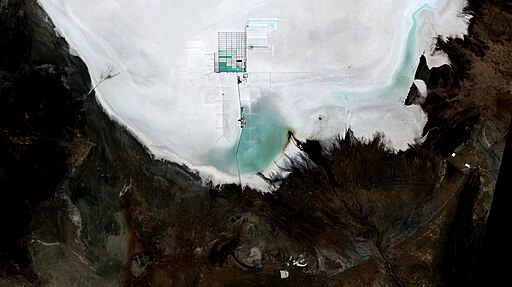

By changing the corresponding pixel array, it is possible to create a pixel array that corresponds to the following, square image which is centered within the existing image:

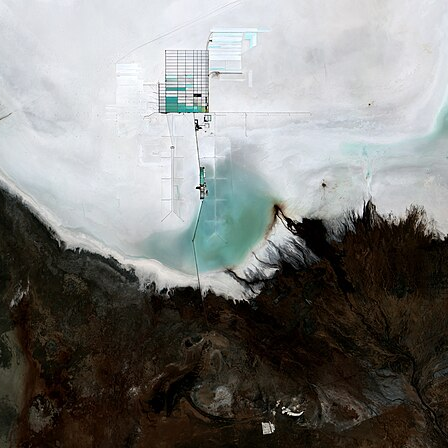

#### 3b. `resize` (10 pts)

Not all of the images will be the exact size as our GWINDOW, but it would be nice if they were. There are many ways to solve this problem, here I will describe one.

One way to resize images is via creating a pixel array of the appropriate size and looping over the entire array, selecting pixels from the original sized image that are in the same relative (e.g. percentage, proportional, fractional) distance across the image in height and width, but may have a different numerical row-by-col location as the numbers of rows/cols differs.

For example, the above image is 448 by 448 pixels, and there is a patch of teal in the center of the image, at around 200-250 by 200-250 pixels. In a 700 by 700 image, that teal patch should be around 300-350 pixels, or so.

#### 3. Finishing Touches

*Of note, you can test squaring and resizing separately prior to this step by simply displaying the pixel arrays as GImages in the GWindow*

Once you have pixel arrays that correspond to images within your `ColorObj`'s, running `flag.py` should produce an image something like this:

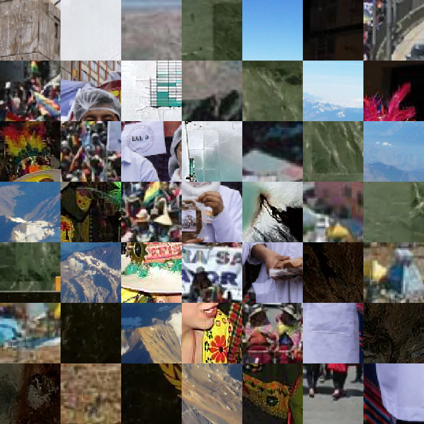

Note the diagonal showing people in labcoats - these are engineers of UMSA, the leading public university in Bolivia, and represent "blanco" which stands for "el desarrollo de la ciencia y la tecnología" (scientific and technologically progress). You can likely also identify the lithium mine.

### 4. ColorScale (20 pts) [Show]

### 4. ColorScale (20 pts) [Hide]

**Implement** `colorscale` **in** `ColorObj` **in** `ColorObj.py`

Our new image does not look so much like the flag we started with, so we will use the same idea as ImageShop.GrayscaleImage to take colorful images and make them look like one color - but in this case, flag colors rather than simply gray.

*Of note, the colorscale will be equivalent to "grayscale" for the color "blanco" (white).*

Once you have read in rgb values and colorscaled the pixel arrays within each ColorObj, your code should produce an image like the following:

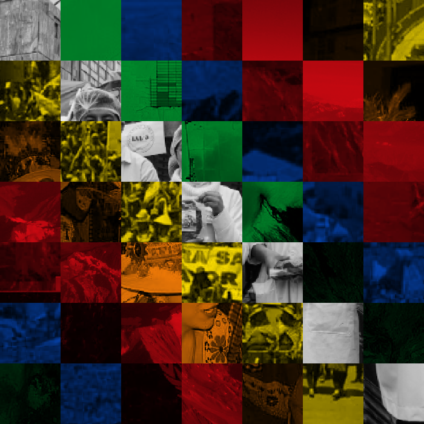

Such an image is indicative of a perfect score on the final exam. Well done! Turn in your code and have a wonderful break.

### Extra Credit (5 pts) [Show]

### Extra Credit (5 pts) [Hide]

Fill out this survey on sections for +5 extra credit. [Link.](https://docs.google.com/forms/d/e/1FAIpQLScOWqXta_3JlJyFUBZx7RGgxQ_hTxcZAafQqPhDcfBUQbe6hg/viewform?usp=pp_url&entry.1763815219=Fall+2025)